# Impact of meteo events in America

Maurice Clere

August 14, 2016

## Synopsis

In this study we will try to answer two questions:

- Which types of meteo events are most harmful to population health in America?
- Which types of meteo events cause the most damage (in $) in America?

Storms and other severe weather events can cause both public health and economic problems for communities and municipalities. Many severe events can result in fatalities, injuries, and property damage, and preventing such outcomes to the extent possible is a key concern.

This project involves exploring the U.S. National Oceanic and Atmospheric Administration’s (NOAA) storm database. This database tracks characteristics of major storms and weather events in the United States, including when and where they occur, as well as estimates of any fatalities, injuries, and property damage.

Extra documentation about this database can be found on those links:

- [Data](https://d396qusza40orc.cloudfront.net/repdata%2Fdata%2FStormData.csv.bz2)
- [Storm data preparation - code book](https://d396qusza40orc.cloudfront.net/repdata%2Fpeer2_doc%2Fpd01016005curr.pdf)
- [FAQ](https://d396qusza40orc.cloudfront.net/repdata%2Fpeer2_doc%2FNCDC%20Storm%20Events-FAQ%20Page.pdf)

## Data Processing

Basic data processing has been done: It mainly consists of subsetting data, handling NA values and unit conversions.

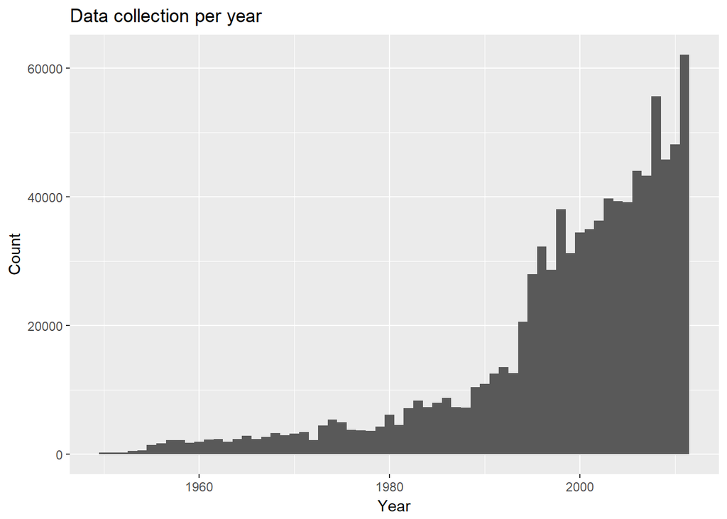

```r
      library(ggplot2)

      storms_db <- read.csv("repdata%2Fdata%2FStormData.csv.bz2")
      storms_db$BGN_DATE <- strptime(storms_db$BGN_DATE, "%m/%d/%Y %H:%M:%S")

      qplot(storms_db$BGN_DATE$year+1900,
            binwidth = 1,
            main = "Data collection per year",
            ylab = "Count",
            xlab = "Year")
```

Data collection is much more complete in the last decade. We will choose to work with the last 10 years of this data set (2001-11-15 –> 2011-11-15).

On top of the period we will also select the columns that are relevant for this study:

- “EVTYPE”: event names
- “FATALITIES” & “INJURIES”: respectively number of fatalities and injuries
- “PRODDMG” & “PRODDMGEXP”: Property damage estimates in US Dollars [$]
- “CROPDMG” & “CROPDMGEXP”: Crop damage estimates in US Dollars [$]

```r
      library(reshape2)
      library(dplyr)

      last_10yrs <- storms_db$BGN_DATE > "2001-11-15 CET"
      selection <- c("EVTYPE","FATALITIES","INJURIES","PROPDMG","PROPDMGEXP","CROPDMG","CROPDMGEXP")
      events_db <- storms_db[last_10yrs,selection]


      # White space is trimmed, all text is converted to uppercase
            storms_db$EVTYPE <- toupper(storms_db$EVTYPE)  # change all the text to upper case
            storms_db$EVTYPE <- trimws(storms_db$EVTYPE)   # remove white spacea beforw and after the text

      # Cases of 0$ damages: set the *DMGEXP columns to 0 also avoid to NA after
            selection <- events_db$CROPDMG == 0
            events_db$CROPDMGEXP[selection] <- 0

            selection <- events_db$PROPDMG == 0
            events_db$PROPDMGEXP[selection] <- 0

      # Cases of the factor level in the *DMGEXP columns is not described in the code book: Set to NA
            events_db$PROPDMGEXP <- gsub("[^MmkKB0]","NAN",events_db$PROPDMGEXP)
            events_db$CROPDMGEXP <- gsub("[^MmkKB0]","NAN",events_db$CROPDMGEXP)

      # convert k (kilo), m(million) and b(billion) to numbers in the *DMGEXP columns
            events_db$PROPDMGEXP <- gsub("k|K","1000",events_db$PROPDMGEXP)
            events_db$PROPDMGEXP <- gsub("m|M","1000000",events_db$PROPDMGEXP)
            events_db$PROPDMGEXP <- gsub("b|B","1000000000",events_db$PROPDMGEXP)

            events_db$CROPDMGEXP <- gsub("k|K","1000",events_db$CROPDMGEXP)
            events_db$CROPDMGEXP <- gsub("m|M","1000000",events_db$CROPDMGEXP)
            events_db$CROPDMGEXP <- gsub("b|B","1000000000",events_db$CROPDMGEXP)

      # Conversion off all DMG columns into $ unit. creation of columns containing the total
            events_db$PROPDMG <- events_db$PROPDMG*as.numeric(events_db$PROPDMGEXP)
            events_db$CROPDMG <- events_db$CROPDMG*as.numeric(events_db$CROPDMGEXP)
            events_db$TOTDMG <- rowSums(events_db[,c("PROPDMG","CROPDMG")],na.rm = TRUE)

      # Selection and agregation of the relevant columns
            selection2 <- c("EVTYPE","FATALITIES","INJURIES","PROPDMG","CROPDMG","TOTDMG")
            events_sum <- events_db[,selection2]%>%
            group_by(EVTYPE)%>%
            summarise_each(funs(sum(.,na.rm=TRUE)))
```

## Results

### Most Harmful meteo events

We will define the “most harmful” by simply counting the numbers of fatalities for each events over those 10 years. Somehow, this approach combines dangerousity and frequency (in the database) of each event. For information, we will also add the number of injuries.

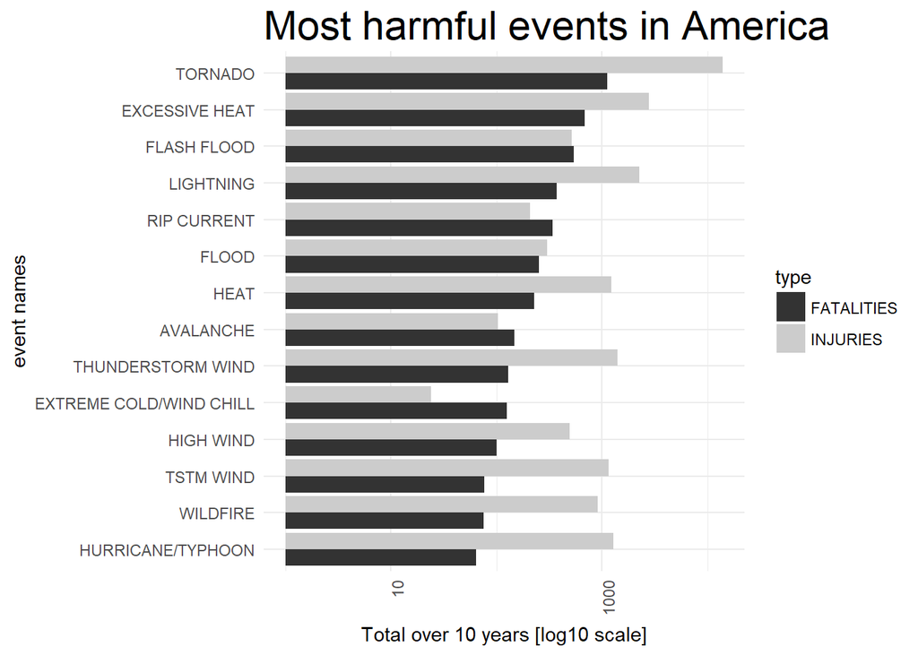

```r
     library(ggplot2)

      # selection of the 10 most important events for injuries and fatalities --------------
            T10_fat <- head(events_sum[order(-events_sum$FATALITIES, - events_sum$INJURIES),],10)
            T10_inj <- head(events_sum[order(-events_sum$INJURIES, - events_sum$FATALITIES),],10)
            top_harmful <- union(T10_fat,T10_inj)


      #plot ---------------------------------------------------------------------------------
      top_harmful$EVTYPE <- factor(top_harmful$EVTYPE,
                                   levels = top_harmful$EVTYPE[order(top_harmful$FATALITIES)])

      top_harmful_m <- melt(data = top_harmful[,c("EVTYPE","FATALITIES","INJURIES")],
                            id.vars = "EVTYPE",
                            variable.name = "type",
                            value.name = "total")

      g <- ggplot(top_harmful_m,aes( EVTYPE, total, fill = type))

      g + geom_bar(stat = "identity", position="dodge")+
            theme_minimal()+
            theme(axis.text.x = element_text(angle = 90, hjust = 1),
                  plot.title = element_text(size=22))+
            coord_flip()+
            scale_y_log10()+
            scale_fill_grey()+
            labs(title = "Most harmful events in America", x="event names", y = "Total over 10 years [log10 scale]")
```

The most harmful events in America is Tornado with a little bit more than 1000 fatalities over 10 years.

### Most damaging meteo events

We will define the “most damaging” by computing the *total* damage cost (properties + crops) for each event over those 10 years. Somehow, this approach combines damaging potential and frequency (in the database) of each event.

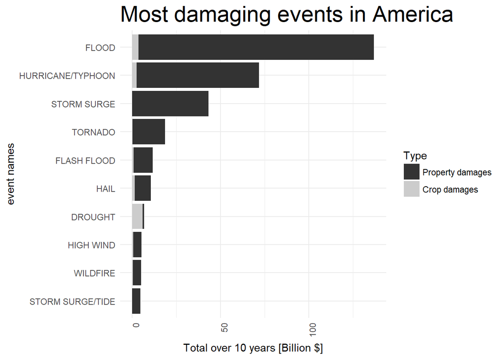

```r
      # selection of the 10 most damaging events--------------------------------------------
      T10_dmg <- head(events_sum[order(-events_sum$TOTDMG),],10)

      T10_dmg$EVTYPE <- factor( T10_dmg$EVTYPE,
                                   levels =  T10_dmg$EVTYPE[order(T10_dmg$TOTDMG)])

      T10_dmg_m <- melt(data= subset(T10_dmg,select=c("EVTYPE","PROPDMG","CROPDMG")),
                      id.vars = "EVTYPE",
                      variable.name = "type",
                      value.name = "total")

      #plot ---------------------------------------------------------------------------------
      p <- ggplot(T10_dmg_m,aes(EVTYPE, total/1000000000,
                                fill = factor(type, labels=c("Property damages","Crop damages"))))

      p+ geom_bar(stat = "identity", position="stack")+
            theme_minimal()+
            scale_fill_grey()+
            coord_flip()+
            theme(axis.text.x = element_text(angle = 90, hjust = 1),plot.title = element_text(size=22))+
            labs(title = "Most damaging events in America", x="event names", y = "Total over 10 years [Billion $]",fill = "Type")
```

In total, flood seems to be, by far, the most costly meteo events in America over those 10 years. It should be noted the special treatment of flood event cost estimates as described in the “Storm data preparation” document. The flood does not have the “no information available” and a number should *always* be provided.